# ASI Workshop: Data Types, Functions, Loops, and PCA Using Single-Cell RNA-seq Data

```r
library(tidyverse)
library(ggside)
library(here)

GSE168944_matrix_path <- here("data", "GSE168944_cell.counts.txt.gz")
n <- 10000

GSE168944_metadata_path <- here("data", "GSE168944_cell.metadata.csv.gz")

theme_set(theme_minimal(base_size = 14))

Sys.setenv("VROOM_CONNECTION_SIZE" = 1e7)


header <- read_lines(GSE168944_matrix_path, n_max = 1)

cell_ids <- str_split(header, pattern = " ")[[1]]
cell_ids <- cell_ids[cell_ids != ""]

final_header <- c("gene", cell_ids)


set.seed(42)

sampled_cells <- sample(cell_ids, size = n)

selected_cols <- c("gene", sampled_cells)

counts_matrix <- read_delim(
  file = GSE168944_matrix_path,
  delim = " ",
  col_names = final_header,
  skip = 1,
  col_select = all_of(selected_cols)
)

counts_matrix <-
  counts_matrix %>%
  rename_with(~ gsub('"', '', .x))

GSE168944_metadata <- read_delim(
  file = GSE168944_metadata_path,
)

# save the main two files we will use
saveRDS(counts_matrix, here("data", "counts_matrix.rds"))
saveRDS(GSE168944_metadata, here("data", "GSE168944_metadata.rds"))

# remove unused objects from the environment
rm(cell_ids, final_header, GSE168944_matrix_path, GSE168944_metadata_path,
   header, n, sampled_cells, selected_cols)
```

# Introduction

## Learning Outcomes

By the end of this workshop you will be able to:

- Explore single-cell RNA-seq count matrices
- Understand metadata associated with cells
- Work with vectors, factors, data frames and tibbles
- Use conditional logic with if/else and if_else()
- Write reusable functions
- Automate analyses using loops
- Compare loops with purrr workflows
- Understand PCA in the context of scRNA-seq
- Interpret PCA scores and loadings
- Identify genes driving principal components
- Interpret biological variation in single-cell datasets

Please note, the solutions are only one of many potential solutions. There are many ways to achieve the same outcomes. However some, as described before, may be more or less efficient.

# Activity 1: Data Types and Objects

## Start

Everything in R is an object. These are the basic data structures.

The dataset we will be using, GSE168944, contains:

- Gene expression counts
- Cell metadata

## Lets have a look at the object information.

## Explore Objects

```r
class(counts_matrix)
```

```
## [1] "tbl_df"     "tbl"        "data.frame"
```

```r
class(GSE168944_metadata)
```

```
## [1] "spec_tbl_df" "tbl_df"      "tbl"         "data.frame"
```

```r
typeof(counts_matrix)
```

```
## [1] "list"
```

```r
typeof(GSE168944_metadata)
```

```
## [1] "list"
```

**Activity 1: Exploring Objects and Dimensions**

class() - Returns the object’s class. - Tells R how the object should behave. - Examples include tibble, data.frame, matrix, factor, character.

typeof() - Returns the underlying storage type. - Examples include list, double, integer and character. - More focused on how data is stored internally.

dim() - Returns the dimensions of an object. - For a table or matrix: - First value = rows - Second value = columns

select() - Selects a subset of columns.

glimpse() - Provides a compact overview of an object. - Displays column names, data types and example values.

These commands are mostly used to inspect objects before doing any analysis.

## Activity

Determine:

- Number of genes
- Number of cells
- Number of metadata variables

```r
# put your solution here
```

### Solution

```r
dim(counts_matrix)
```

```
## [1] 16136 10001
```

```r
dim(GSE168944_metadata)
```

```
## [1] 64449    19
```

```r
counts_matrix %>% select(1:3) %>% glimpse()
```

```
## Rows: 16,136
## Columns: 3
## $ gene                  <chr> "Mrpl15", "Lypla1", "Gm37988", "Tcea1", "Atp6v1h…
## $ DJ22_CATCGAAAGTTCGCAT <dbl> 0, 0, 0, 0, 0, 0, 0, 0, 0, 0, 0, 0, 0, 0, 0, 0, …
## $ DJ23_TCGGTAAAGTTATCGC <dbl> 1, 0, 0, 5, 0, 0, 0, 0, 0, 0, 1, 0, 0, 0, 0, 0, …
```

```r
GSE168944_metadata %>% select(1:3) %>% glimpse()
```

```
## Rows: 64,449
## Columns: 3
## $ barcode <chr> "DJ01_AAACCTGAGACACGAC", "DJ01_AAACCTGAGCACAGGT", "DJ01_AAACCT…
## $ nGene   <dbl> 3673, 3706, 2886, 4947, 3183, 1737, 4138, 2787, 3257, 4881, 24…
## $ nUMI    <dbl> 15713, 16798, 9889, 31301, 15141, 4553, 21871, 10036, 14025, 2…
```

# Activity 2: Preparing the Expression Matrix

## Start

Our first column are gene ids, the rest are cell ids.

For PCA we need:

- Rows = cells
- Columns = genes

This is because PCA expects observations in rows and variables as columns.

## Create an Expression Matrix

```r
expr_mat <- counts_matrix %>%
  column_to_rownames("gene") %>%
  as.matrix()

dim(expr_mat)
```

```
## [1] 16136 10000
```

## Transpose the Matrix

```r
expr_cells <- t(expr_mat)

dim(expr_cells)
```

```
## [1] 10000 16136
```

## Discussion

What do rows and columns represent now?

# Activity 3: Exploring Metadata

## Start

In this dataset the metadata describes each cell. In general, metatadata describes unit level data (e.g. the granular data about the single specific subject).

Examples include for GSE168944:

- Tissue
- Cluster
- Cell cycle phase
- Sequencing depth
- Mitochondrial percentage

## Activity

Inspect the metadata. Please note glimpse will exhaustively print all columns - hence the subset.

```r
# put your solution here
```

### Solution

```r
GSE168944_metadata %>% select(1:3) %>% glimpse()
```

```
## Rows: 64,449
## Columns: 3
## $ barcode <chr> "DJ01_AAACCTGAGACACGAC", "DJ01_AAACCTGAGCACAGGT", "DJ01_AAACCT…
## $ nGene   <dbl> 3673, 3706, 2886, 4947, 3183, 1737, 4138, 2787, 3257, 4881, 24…
## $ nUMI    <dbl> 15713, 16798, 9889, 31301, 15141, 4553, 21871, 10036, 14025, 2…
```

## Summarise Categories

```r
GSE168944_metadata %>%
  count(Cluster)
```

```
## # A tibble: 33 × 2
##    Cluster               n
##    <chr>             <int>
##  1 C01_CD8_Tn        14435
##  2 C02_CD8_Tscm        510
##  3 C03_CD8_Gzmm       1273
##  4 C04_CD8_KLR        1071
##  5 C05_CD8_Teff        422
##  6 C06_CD8_Tem_ISG     492
##  7 C07_CD8_Tex_ISG    1588
##  8 C08_CD8_Tex_Cd244  4788
##  9 C09_CD8_Tex_Ccr7   3700
## 10 C10_CD8_Tex_Gzmc   1401
## # ℹ 23 more rows
```

```r
GSE168944_metadata %>%
  count(Tissue)
```

```
## # A tibble: 4 × 2
##   Tissue     n
##   <chr>  <int>
## 1 Blood  11647
## 2 Spleen 17955
## 3 Tumor  19824
## 4 dLN    15023
```

```r
GSE168944_metadata %>%
  count(Phase)
```

```
## # A tibble: 3 × 2
##   Phase     n
##   <chr> <int>
## 1 G1    61586
## 2 G2M    1760
## 3 S      1103
```

# Activity 4: Matching Cells Between Datasets

## Start

Metadata and expression matrices must have matching cell names.

## Match Metadata and Counts

```r
metadata <- GSE168944_metadata %>%
  filter(barcode %in% rownames(expr_cells))

expr_cells <- expr_cells[
  metadata$barcode,
]

all(
  rownames(expr_cells) ==
    metadata$barcode
)
```

```
## [1] TRUE
```

Depending on how you need the data, a left or right join will also remove unneeded data.

```r
expr_mat_meta <- as_tibble(expr_cells, rownames = "barcode") %>%
  left_join(GSE168944_metadata, by = "barcode")

expr_mat_meta %>% select((last_col() - 5):last_col())
```

```
## # A tibble: 10,000 × 6
##    Mouse Tissue orig.ident Cluster            NT_clonotype          AA_clonotype
##    <chr> <chr>       <dbl> <chr>              <chr>                 <chr>
##  1 m01   Tumor         7.1 C07_CD8_Tex_ISG    TRA:TRAV16_TRAJ43_TG… TRA:TRAV16_…
##  2 m01   Tumor         3   C11_CD8_Tex_Ccl3   TRA:TRAV7d-2_TRAJ39_… TRA:TRAV7d-…
##  3 m01   Tumor        10.1 C17_CD4_Th1        TRA:TRAV16_TRAJ39_TG… TRA:TRAV16_…
##  4 m01   Tumor         7.1 C07_CD8_Tex_ISG    TRA:TRAV16d-dv11_TRA… TRA:TRAV16d…
##  5 m01   Tumor        14   C13_CD8_Mki67      TRA:TRAV7d-2_TRAJ39_… TRA:TRAV7d-…
##  6 m01   Tumor         4.2 C33_Mixed_Tex_Treg TRA:TRAV3-3_TRAJ23_T… TRA:TRAV3-3…
##  7 m01   Tumor         3   C09_CD8_Tex_Ccr7   TRA:TRAV6-7-dv9_TRAJ… TRA:TRAV6-7…
##  8 m01   Tumor         9.1 C12_CD8_Mki67_E2F  TRA:TRAV14d-2_TRAJ24… TRA:TRAV14d…
##  9 m01   Tumor         7.1 C07_CD8_Tex_ISG    TRA:TRAV14d-2_TRAJ24… TRA:TRAV14d…
## 10 m01   Tumor         3   C08_CD8_Tex_Cd244  TRA:TRAV7-5_TRAJ30_T… TRA:TRAV7-5…
## # ℹ 9,990 more rows
```

**Activity 2–4: Creating and Aligning Expression Matrices**

column_to_rownames() - Takes a column and converts it into row names. - Removes the original column from the table.

as.matrix() - Converts a tibble/data frame into a matrix.

t() - Transposes a matrix. - Rows become columns. - Columns become rows.

filter() - Keeps rows matching a condition.

%in% - Checks whether values exist inside another vector.

rownames() - Returns row names from a matrix or data frame.

all() - Tests whether every comparison returns TRUE. - Often used as a validation step.

left_join() - Merges data from another table. - Preserves all rows from the left table. - Matches rows using a common column.

as_tibble() - Converts an object into a tibble.

These commands convert data into matrix form and ensure rows are correctly matched between datasets.

# Activity 5: Working with Tibbles

## Activity

Determine:

- The number of rows
- The number of columns
- The number of missing values

```r
# put your solution here
```

### Solution

```r
nrow(metadata)
```

```
## [1] 10000
```

```r
ncol(metadata)
```

```
## [1] 19
```

```r
metadata %>%
  summarise(
    across(
      everything(),
      ~sum(is.na(.))
    )
  )
```

```
## # A tibble: 1 × 19
##   barcode nGene  nUMI nCount_RNA nFeature_RNA percent.mito S.Score G2M.Score
##     <int> <int> <int>      <int>        <int>        <int>   <int>     <int>
## 1       0     0     0          0            0            0       0         0
## # ℹ 11 more variables: Phase <int>, old.ident <int>, CC.Difference <int>,
## #   Batch <int>, Sample <int>, Mouse <int>, Tissue <int>, orig.ident <int>,
## #   Cluster <int>, NT_clonotype <int>, AA_clonotype <int>
```

# Activity 6: Exploring QC Metrics

## Start

Common quality metrics include:

- nGene
- nUMI
- percent.mito

## Calculate Summary Statistics

```r
metadata %>%
  summarise(
    mean_genes = mean(nGene),
    mean_umi = mean(nUMI),
    mean_mito = mean(percent.mito)
  )
```

```
## # A tibble: 1 × 3
##   mean_genes mean_umi mean_mito
##        <dbl>    <dbl>     <dbl>
## 1      2173.    7191.    0.0267
```

## Visualise QC Metrics

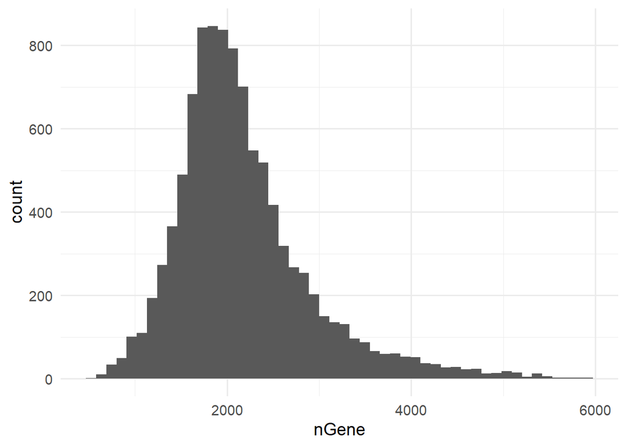

```r
ggplot(
  metadata,
  aes(nGene)
) +
  geom_histogram(
    bins = 50
  )
```

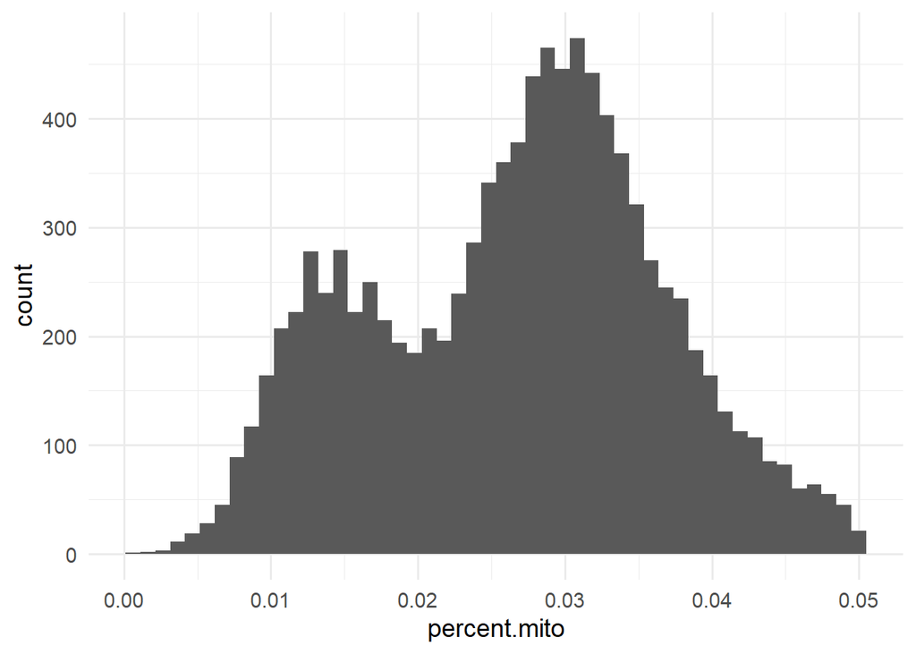

```r
ggplot(
  metadata,
  aes(percent.mito)
) +
  geom_histogram(
    bins = 50
  )
```

**Activity 5–6: Summaries, Missing Values and Visualisation**

nrow() - Returns the number of rows.

ncol() - Returns the number of columns.

summarise() - Creates summary statistics.

across() - Applies the same calculation to multiple columns.

everything() - Selects all columns.

is.na() - Identifies missing values.

sum() - Counts the number of TRUE values. - Often used to count missing values.

mean() - Calculates the arithmetic mean.

ggplot() - Creates a plot object.

aes() - Maps variables to plot aesthetics such as x, y, colour or fill.

geom_histogram() - Creates a histogram. - Used to visualise distributions.

bins = - Controls the number of histogram bins.

These commands are used to inspect datasets, calculate summaries and visualise distributions.

# Activity 7: Conditional Logic

## Start

Conditional logic is the ‘backbone’ of many different analysis and coding challenges.

## Worked Example - if we have mito at 12% but 10% is our cutoff

```r
mito <- 0.12

if(mito > 0.1){

  print("Low quality cell")

} else {

  print("High quality cell")
}
```

```
## [1] "Low quality cell"
```

## Activity

Create a QC classification variable. Note this is an already cleaned dataset so we are setting the percent mito very low.

```r
# put your solution here
```

### Solution

```r
metadata <- metadata %>%
  mutate(
    qc_class =
      if_else(
        percent.mito > 0.01,
        "LowQuality",
        "HighQuality"
      )
  )
```

# Activity 8: Vectorised Logic

## Activity

**Create categories for all cells simultaneously. This is basically replacing chaining if_else statements - reads cleaner.**

```r
# put your solution here
```

### Solution

```r
metadata <- metadata %>%
  mutate(
    qc_class =
      case_when(
        percent.mito < 0.01 ~ "Excellent",
        percent.mito < 0.02 ~ "Good",
        TRUE ~ "Poor"
      )
  )
```

**Activity 7–8: Conditional Logic and Classification**

if() - Evaluates a condition. - Runs code only if the condition is TRUE.

else() - Runs alternative code when the condition is FALSE.

print() - Displays output.

mutate() - Creates or modifies columns.

if_else() - Vectorised version of if/else. - Evaluates every value in a column. - Returns one value for TRUE and another for FALSE.

case_when() - Handles multiple conditions. - Evaluates rules from top to bottom. - Returns the result from the first matching condition.

TRUE ~ - Acts as a default catch-all condition.

These commands are used to create categories and make decisions based on data values.

# Activity 9: Functions

## Start

Functions allow code reuse. This is important and much better than copy and pasting the same code a million times! Below is the formula for the percentage coefficient of variation (CV), you don’t want to have to write this out every time!

## Worked Example

```r
cv <- function(x){

  sd(x, na.rm = TRUE) /
    mean(x, na.rm = TRUE) *
    100

}
```

## Activity

Calculate the CV for metadata variables. Here we call cv() with the x input being a numeric vector. We access this from the metadata by accessing the named list using tibble$named_list.

```r
# put your solution here
```

### Solution

```r
cv(metadata$nGene)
```

```
## [1] 33.74899
```

```r
cv(metadata$nUMI)
```

```
## [1] 59.68894
```

```r
cv(metadata$percent.mito)
```

```
## [1] 36.91135
```

# Activity 10: Functions Returning Tables

## Create Summary Function

This can be quite useful for example, many times when you are reporting say a metric such as the difference between two groups, you might want to able to quickly summarise the data.

```r
summary_stats <- function(x){

  tibble(
    mean = mean(x, na.rm = TRUE),
    sd = sd(x, na.rm = TRUE),
    min = min(x, na.rm = TRUE),
    max = max(x, na.rm = TRUE)
  )

}
```

## Test the Function

```r
summary_stats(metadata$nGene)
```

```
## # A tibble: 1 × 4
##    mean    sd   min   max
##   <dbl> <dbl> <dbl> <dbl>
## 1 2173.  733.   524  5917
```

```r
summary_stats(metadata$nUMI)
```

```
## # A tibble: 1 × 4
##    mean    sd   min   max
##   <dbl> <dbl> <dbl> <dbl>
## 1 7191. 4292.   900 49239
```

**Activity 9–10: Writing and Using Functions**

function() - Creates a reusable block of code. - Inputs are supplied through arguments.

Example: function(x)

x - Represents the value passed into the function.

sd() - Calculates standard deviation.

mean() - Calculates the average value.

min() - Returns the smallest value.

max() - Returns the largest value.

na.rm = TRUE - Removes missing values before calculating.

tibble() - Creates a tibble object. - Useful when returning multiple values from a function.

return value - A function automatically returns the final object it evaluates. - In these examples this is either a number or a tibble.

Functions allow the same calculation to be reused without rewriting code.

# Activity 11: Loops

## Start

Loops automate repetitive calculations. For example, you want to loop through and perform a complex calculation on each row of a dataframe, that can’t be vectorised.

## Simple Loop

```r
for(i in 1:5){

  print(i)

}
```

```
## [1] 1
## [1] 2
## [1] 3
## [1] 4
## [1] 5
```

## Loop Through Variables

```r
vars <- c(
  "nGene",
  "nUMI",
  "percent.mito"
)

for(v in vars){

  print(v)

  print(
    mean(
      metadata[[v]],
      na.rm = TRUE
    )
  )

}
```

```
## [1] "nGene"
## [1] 2172.966
## [1] "nUMI"
## [1] 7191.395
## [1] "percent.mito"
## [1] 0.02668676
```

# Activity 12: Storing Results from Loops

Depending on what you need, most of the time you will need to store data from a loop. For example, we use a loop to calculate the mean of the variables. This can be achieved in a number of ways, but below we init an empty vector of length vars. The loop then iterates along vars, and stores the means the the vector slots.

## Solution

```r
results <- numeric(
  length(vars)
)

for(i in seq_along(vars)){

  results[i] <-
    mean(
      metadata[[vars[i]]],
      na.rm = TRUE
    )

}

names(results) <- vars

results
```

```
##        nGene         nUMI percent.mito
## 2.172966e+03 7.191395e+03 2.668676e-02
```

# Activity 13: Loops versus purrr

## purrr Solution

Overall, I would say Purrr map_x supersedes writing a manual loop. But good to know how it works if you need more granular control, or you need to maximise memory.

There are also sapply, lapply, vapply, and apply in base R which are also quite useful. Purrr is the tidy version of these. For example, lapply will apply a function to each element of a list. Note, dataframes are lists of columns.

```r
map_dbl(
  metadata[vars],
  mean,
  na.rm = TRUE
)
```

```
##        nGene         nUMI percent.mito
## 2.172966e+03 7.191395e+03 2.668676e-02
```

## Discussion

Advantages of:

- Loops
- apply family
- purrr

**Activity 11–13: Loops, Iteration and purrr**

for() - Repeats code multiple times. - Iterates over a sequence of values.

Example: for(i in 1:5)

i - Stores the current value during each iteration.

c() - Combines values into a vector.

metadata[[v]] - Dynamically selects a column by name. - Useful when looping through multiple variables.

numeric() - Creates an empty numeric vector. - Often used to preallocate storage before a loop.

length() - Returns the number of elements in an object.

seq_along() - Generates a sequence matching the length of another object. - Safer than hardcoding index values.

results[i] <- - Stores output into a specific location.

names() - Assigns names to vector elements.

map_dbl() - Applies a function to each element of a list-like object. - Returns a numeric vector. - Equivalent to many simple loops.

Loop workflow: 1. Create storage object. 2. Iterate through values. 3. Perform calculation. 4. Store result. 5. Return completed object.

These commands automate repetitive calculations across multiple variables.

# Activity 14: Introduction to PCA

## Why PCA?

Single-cell datasets contain:

- ~20k genes - Note single cell full length transcriptomics will contain hundreds of thousands of transcripts for these 20k genes.
- Thousands to millions of cells

Many genes are correlated.

PCA reduces this high-dimensional data into a small number of informative components.

# Activity 15: Select Highly Variable Genes

## Start

Using all genes can introduce noise.

We first identify highly variable genes.

## Calculate Gene Variance

```r
gene_var <- apply(
  expr_cells,
  2,
  var
)

top_genes <- names(
  sort(
    gene_var,
    decreasing = TRUE
  )[1:2000]
)
```

## Subset Variable Genes

```r
expr_hvg <- expr_cells[
  ,
  top_genes
]

dim(expr_hvg)
```

```
## [1] 10000  2000
```

# Activity 16: Log Transformation

## Start

Raw counts are highly skewed.

A log transformation stabilises variance.

## Transform Counts

```r
expr_log <- log1p(
  expr_hvg
)
```

# Activity 17: Running PCA

## Activity

Run PCA.

```r
# put your solution here
```

### Solution

```r
sc_pca <- prcomp(
  expr_log,
  center = TRUE,
  scale. = TRUE
)

summary(sc_pca)
```

[output not shown]

[output cut: 1078 more lines]

[output not shown]

# Activity 18: Variance Explained

## Start

PC1 explains the greatest amount of variation.

PC2 explains the next largest amount.

PCn should be capturing different pattern not in other PCs.

## Interpretation Questions

1. How much variance does PC1 explain?
2. How much variance do PC1 and PC2 explain?
3. How many PCs explain more than 80% of the variance?

```r
# put your answers here

# Q1.

# Q2.

# Q3.
```

## Solution

```r
which(summary(sc_pca)$importance[3, ] >= 0.80)[1]
```

```
## PC878
##   878
```

**Activity 14–18: Variance Calculations and PCA**

apply() - Applies a function across rows or columns of a matrix.

apply(expr_cells, 2, var)

2 - Means operate across columns.

var() - Calculates variance.

sort() - Orders values.

decreasing = TRUE - Sorts largest to smallest.

names() - Retrieves element names.

[1:2000] - Selects the first 2000 values.

Matrix subsetting: expr_cells[, top_genes]

- Keeps all rows.
- Selects only chosen columns.

log1p() - Calculates log(1 + x). - Prevents issues with zero values.

prcomp() - Performs Principal Component Analysis.

center = TRUE - Mean-centres variables before PCA.

scale. = TRUE - Standardises variables before PCA.

summary() - Returns PCA summaries. - Includes variance explained.

which() - Finds positions where a condition is TRUE.

importance[3, ] - Extracts cumulative variance explained.

> = 0.80 - Finds components explaining at least 80% cumulative variance.

These commands identify variable features, transform data and perform PCA.

# Activity 19: PCA Scores

## Start

Scores describe where cells sit in PCA space. We can extract the specific cells PCA score (fun fact - you can use this in machine learning as a method to reduce colinearity of variables and to reduce dimensions).

## Extract Scores

```r
scores <- as_tibble(
  sc_pca$x,
  rownames = "barcode"
)

scores <- scores %>%
  left_join(
    metadata,
    by = "barcode"
  )

head(scores)
```

```
## # A tibble: 6 × 2,020
##   barcode       PC1    PC2    PC3    PC4    PC5     PC6   PC7   PC8   PC9   PC10
##   <chr>       <dbl>  <dbl>  <dbl>  <dbl>  <dbl>   <dbl> <dbl> <dbl> <dbl>  <dbl>
## 1 DJ01_AAAC… -50.4    3.15  0.237 -6.27   1.57   -0.210  5.73 -1.43  2.04  1.98
## 2 DJ01_AAAC… -84.3  -21.7  13.5   -6.23  25.0   -20.6    6.37  2.82 17.4  -4.61
## 3 DJ01_AAAC…   1.56   8.87 -2.96  -3.81   2.54    2.28  -2.66  1.41 -1.52 -0.766
## 4 DJ01_AAAC…  13.8   18.1   3.38  -0.817 -1.65   -2.41  12.4  -5.25  2.94 -0.672
## 5 DJ01_AAAC… -37.2    3.43  1.07  -6.30   0.206   1.57  -3.41 -3.83 -6.91 -1.33
## 6 DJ01_AAAC…  20.9   27.6   9.63   4.26   5.63    5.09  -5.36 -3.66 11.7  -3.82
## # ℹ 2,009 more variables: PC11 <dbl>, PC12 <dbl>, PC13 <dbl>, PC14 <dbl>,
## #   PC15 <dbl>, PC16 <dbl>, PC17 <dbl>, PC18 <dbl>, PC19 <dbl>, PC20 <dbl>,
## #   PC21 <dbl>, PC22 <dbl>, PC23 <dbl>, PC24 <dbl>, PC25 <dbl>, PC26 <dbl>,
## #   PC27 <dbl>, PC28 <dbl>, PC29 <dbl>, PC30 <dbl>, PC31 <dbl>, PC32 <dbl>,
## #   PC33 <dbl>, PC34 <dbl>, PC35 <dbl>, PC36 <dbl>, PC37 <dbl>, PC38 <dbl>,
## #   PC39 <dbl>, PC40 <dbl>, PC41 <dbl>, PC42 <dbl>, PC43 <dbl>, PC44 <dbl>,
## #   PC45 <dbl>, PC46 <dbl>, PC47 <dbl>, PC48 <dbl>, PC49 <dbl>, PC50 <dbl>, …
```

```r
saveRDS(scores, here("data", "PCA_scores.rds"))
```

# Activity 20: PCA by Cluster

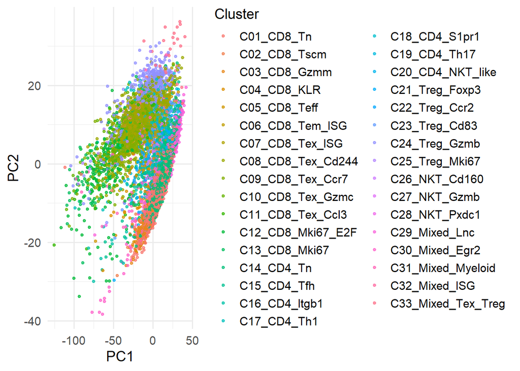

```r
ggplot(
  scores,
  aes(
    PC1,
    PC2,
    colour = Cluster
  )
) +
  geom_point(
    alpha = 0.7,
    size = 1
  )
```

## Interpretation Questions

1. Do clusters separate?
2. Are there outliers?
3. Which clusters overlap?

```r
# put your answers here

# Q1.

# Q2.

# Q3.
```

# Activity 21: PCA by Tissue

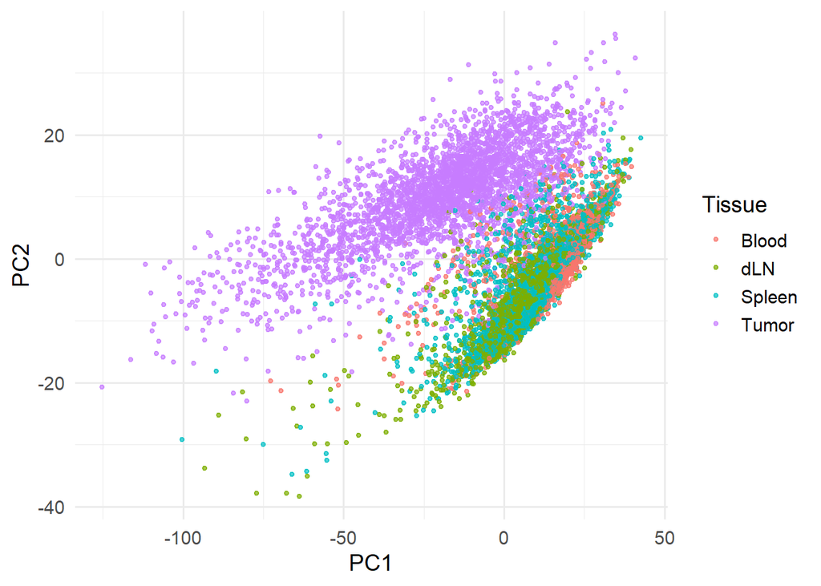

```r
ggplot(
  scores,
  aes(
    PC1,
    PC2,
    colour = Tissue
  )
) +
  geom_point(
    alpha = 0.7,
    size = 1
  )
```

# Activity 22: PCA by Batch

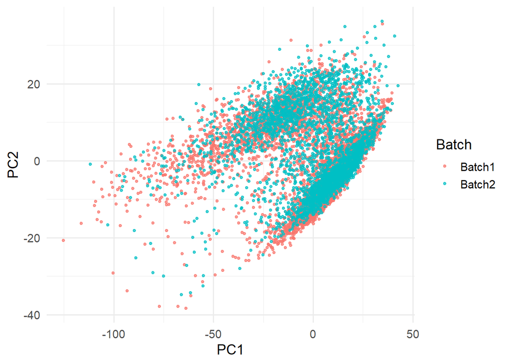

```r
ggplot(
  scores,
  aes(
    PC1,
    PC2,
    colour = Batch
  )
) +
  geom_point(
    alpha = 0.7,
    size = 1
  )
```

# Activity 23: PCA Loadings

## Start

Loadings identify which genes drive each principal component.

## Extract Loadings

```r
loadings <- as_tibble(
  sc_pca$rotation,
  rownames = "gene"
)

loadings
```

```
## # A tibble: 2,000 × 2,001
##    gene         PC1      PC2     PC3      PC4      PC5      PC6      PC7     PC8
##    <chr>      <dbl>    <dbl>   <dbl>    <dbl>    <dbl>    <dbl>    <dbl>   <dbl>
##  1 Gm42418 -0.00953 -0.0355  -0.0174  0.0126  -0.00278  2.97e-2  2.93e-4 -0.0109
##  2 Tmsb4x  -0.0393   0.00465 -0.0307  0.00239 -0.0117  -5.49e-3 -4.05e-2 -0.0225
##  3 Actb    -0.0372  -0.0117  -0.0140  0.0266   0.0229   3.62e-3 -1.33e-2 -0.0844
##  4 Eef1a1  -0.0327  -0.0479  -0.0526 -0.0332  -0.00412  1.17e-2  1.11e-2  0.0368
##  5 Tmsb10  -0.0259  -0.0530  -0.0167  0.0122  -0.0118   4.07e-4  9.30e-3 -0.0248
##  6 Actg1   -0.0369   0.0182  -0.0104  0.0141   0.0159  -1.54e-2 -1.40e-2 -0.0522
##  7 Rps15a  -0.0316  -0.0432  -0.0623 -0.0346  -0.0264   9.21e-3  1.31e-2  0.0539
##  8 Rps24   -0.0156  -0.0800  -0.0387 -0.0275  -0.0178   1.09e-2  2.94e-2  0.0520
##  9 Rpl41   -0.0195  -0.0593  -0.0162 -0.0485   0.0733   7.61e-2  4.45e-2 -0.0127
## 10 Rpsa    -0.0290  -0.0612  -0.0324 -0.0215  -0.00493 -2.06e-3  2.57e-2  0.0442
## # ℹ 1,990 more rows
## # ℹ 1,992 more variables: PC9 <dbl>, PC10 <dbl>, PC11 <dbl>, PC12 <dbl>,
## #   PC13 <dbl>, PC14 <dbl>, PC15 <dbl>, PC16 <dbl>, PC17 <dbl>, PC18 <dbl>,
## #   PC19 <dbl>, PC20 <dbl>, PC21 <dbl>, PC22 <dbl>, PC23 <dbl>, PC24 <dbl>,
## #   PC25 <dbl>, PC26 <dbl>, PC27 <dbl>, PC28 <dbl>, PC29 <dbl>, PC30 <dbl>,
## #   PC31 <dbl>, PC32 <dbl>, PC33 <dbl>, PC34 <dbl>, PC35 <dbl>, PC36 <dbl>,
## #   PC37 <dbl>, PC38 <dbl>, PC39 <dbl>, PC40 <dbl>, PC41 <dbl>, PC42 <dbl>, …
```

# Activity 24: Genes Driving PC1

```r
loadings %>%
  mutate(
    abs_PC1 = abs(PC1)
  ) %>%
  arrange(
    desc(abs_PC1)
  ) %>%
  slice(1:20) %>%
  select(gene, PC1, abs_PC1)
```

```
## # A tibble: 20 × 3
##    gene         PC1 abs_PC1
##    <chr>      <dbl>   <dbl>
##  1 Tmsb4x   -0.0393  0.0393
##  2 Gapdh    -0.0387  0.0387
##  3 B2m      -0.0375  0.0375
##  4 Pfn1     -0.0375  0.0375
##  5 Ppia     -0.0374  0.0374
##  6 Actb     -0.0372  0.0372
##  7 Rbm3     -0.0371  0.0371
##  8 Actg1    -0.0369  0.0369
##  9 Ubb      -0.0367  0.0367
## 10 Cox8a    -0.0365  0.0365
## 11 Anxa2    -0.0365  0.0365
## 12 Cfl1     -0.0364  0.0364
## 13 Oaz1     -0.0361  0.0361
## 14 H2-D1    -0.0360  0.0360
## 15 Clic1    -0.0359  0.0359
## 16 Lgals1   -0.0359  0.0359
## 17 Ldha     -0.0358  0.0358
## 18 Sh3bgrl3 -0.0357  0.0357
## 19 Txn1     -0.0357  0.0357
## 20 Calm1    -0.0354  0.0354
```

# Activity 25: Visualising Loadings

## Plot Contributions to PC1

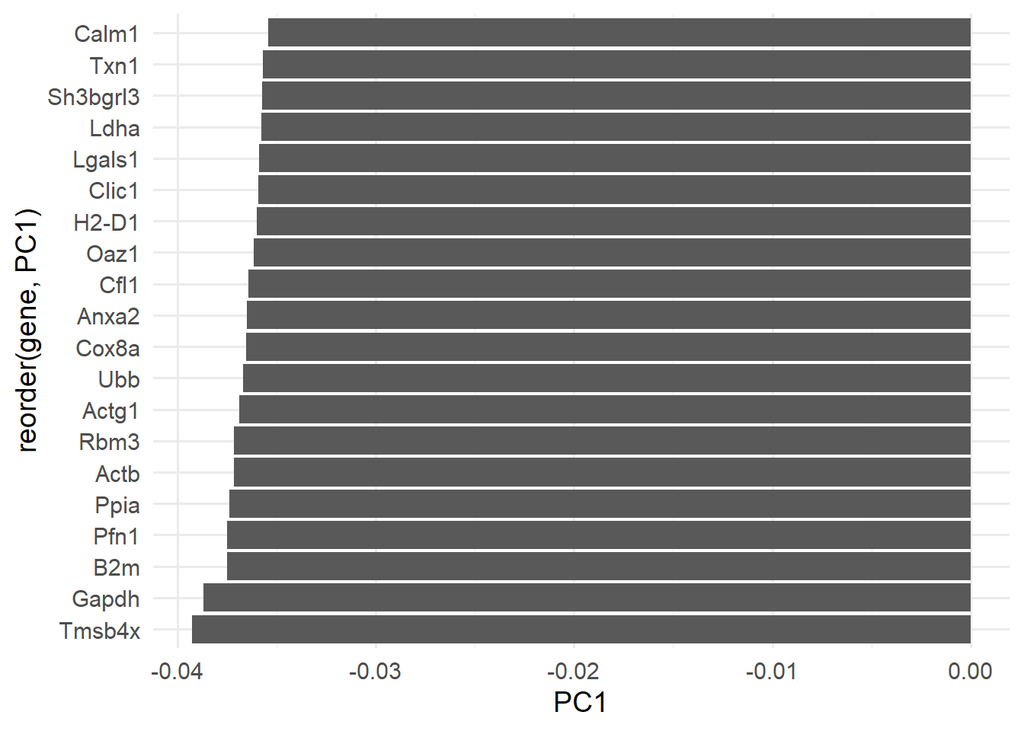

```r
loadings %>%
  mutate(
    abs_PC1 = abs(PC1)
  ) %>%
  slice_max(
    abs_PC1,
    n = 20
  ) %>%
  ggplot(
    aes(
      reorder(gene, PC1),
      PC1
    )
  ) +
  geom_col() +
  coord_flip()
```

# Activity 26: PCA with ggside

ggside is a useful tool for adding side plots to other graphs. This is useful, for example in PCA a KDE can more elegantly describe the distribution differences between PC1 and PC2.

## Plot KDE for the PCA highlighting tissue

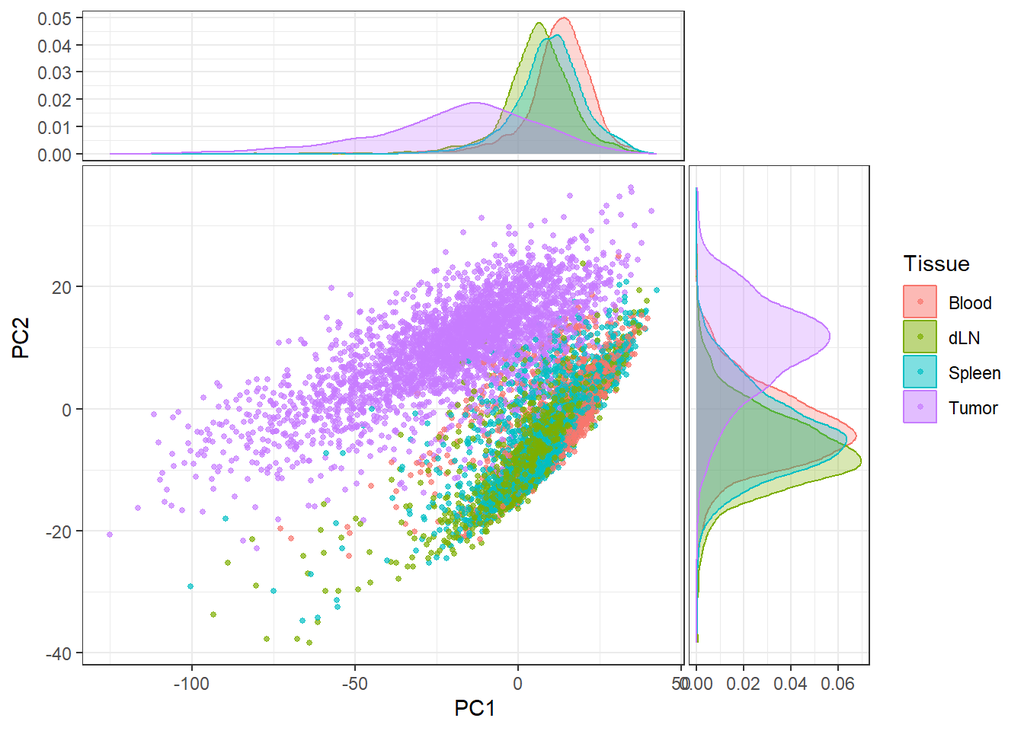

```r
ggplot(
  scores,
  aes(
    PC1,
    PC2,
    colour = Tissue,
    fill = Tissue
  )
) +
  geom_point(
    alpha = 0.7,
    size = 1
  ) +
  geom_xsidedensity(
    alpha = 0.3
  ) +
  geom_ysidedensity(
    alpha = 0.3
  ) +
  theme_bw() +
  theme(
    ggside.panel.scale = 0.3
  )
```

## Plot boxplot for the PCA highlighting tissue

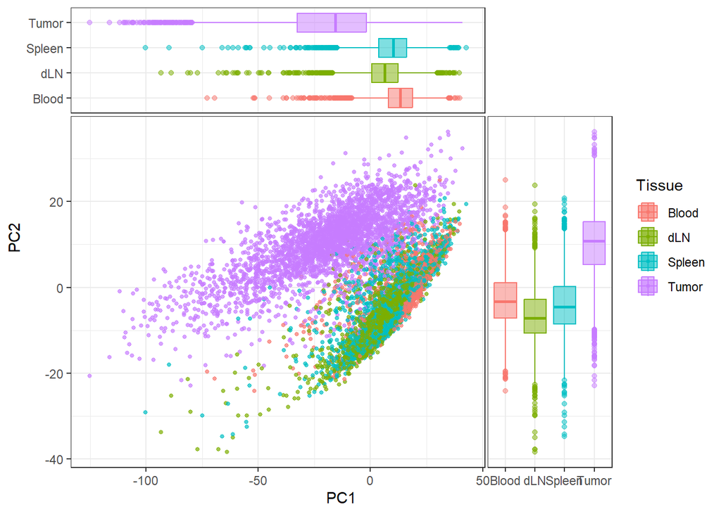

```r
ggplot(
  scores,
  aes(
    PC1,
    PC2,
    colour = Tissue,
    fill = Tissue
  )
) +
  geom_point(
    alpha = 0.7,
    size = 1
  ) +
  geom_xsideboxplot(
    aes(
      y = Tissue
    ),
    alpha = 0.5,
    orientation = "y"
  ) +
  geom_ysideboxplot(
    aes(
      x = Tissue
    ),
    alpha = 0.5,
    orientation = "x"
  ) +
  theme_bw() +
  theme(
    ggside.panel.scale = 0.3
  )
```

Using all outputs generated so far:

Determine:

1. Which genes contribute most strongly to PC1?
2. Which genes contribute most strongly to PC2?
3. How much variance is explained by the first two PCs?
4. Do clusters separate in PCA space?
5. Does Tissue explain variation?
6. Does Batch explain variation?
7. Are there obvious outlier cells?

```r
# put your answers here

# Q1.

# Q2.

# Q3.

# Q4.

# Q5.

# Q6.

# Q7.
```

**Activity 19–26: PCA Scores, Loadings and Visualisation**

sc_pca$x - PCA scores. - Coordinates of observations in PCA space.

sc_pca$rotation - PCA loadings. - Contribution of variables to each principal component.

as_tibble() - Converts PCA output into a tibble.

left_join() - Adds metadata to PCA results.

head() - Displays the first rows.

saveRDS() - Saves an R object to disk.

abs() - Returns absolute values. - Useful when ranking largest positive and negative effects together.

arrange() - Sorts rows.

desc() - Sorts from largest to smallest.

slice() - Selects rows by position.

slice_max() - Selects rows with the largest values.

select() - Chooses output columns.

reorder() - Changes plotting order based on a variable.

ggplot() - Creates a plot object.

geom_point() - Creates scatter plots.

colour = - Colours points by a grouping variable.

fill = - Fills areas based on a grouping variable.

geom_col() - Creates bar charts using supplied values.

coord_flip() - Swaps x and y axes.

theme_bw() - Applies a black-and-white theme.

theme() - Customises plot appearance.

geom_xsidedensity() - Adds density plots along the x-axis.

geom_ysidedensity() - Adds density plots along the y-axis.

geom_xsideboxplot() - Adds boxplots to the x-axis margin.

geom_ysideboxplot() - Adds boxplots to the y-axis margin.

alpha = - Controls transparency.

size = - Controls point size.

orientation = - Controls boxplot orientation.